# Multivariate Linear Regression I

Manu Navjeevan

8/27/2020

## Lecture’s Objective

The goal for this lecture is to familiarize ourselves with multivariate regression in R. As we’ll see, the basic code structure is very similar to that of single regression. We will be using some of the results and formulas that we covered in the main lecture of Econ 103 along the way. Much of our discussion is based on "*Principles of Econometrics with R" by Constantin Colonescu (available for free at https://bookdown.org/ccolonescu/RPoE4/)

## Some Basics

We have so far seen how to run a regression in R with a constant and a single variable. We would like to extend our analysis to the richer model
$$Y = \beta_0 + \beta_1 X_1 + \ldots + \beta_k X_k + \epsilon$$
To illustrate how to analyze this model in R we will work with the CPS data (this is the dataset containing information on income, education, and experience). Let’s begin by loading the relevant data into our workspace so that we can analyze it.

```r
# Clear the workspace
rm(list = ls())

# Our data set is store as part of the PoEData library, so let's tell R we need access to it
library(PoEdata)

# Remember that if we are not sure about the data set name, we can use data() to learn what is available
data()

# Looking at the output, there are multiple datasets called CPS. We'll use cps.
data(cps)
```

If you look at the Environment tab on the upper right hand corner you should see that a new dataset `cps` is now available in the workspace. Let’s begin by running a single regression of log-income on education to refresh our memory. Remember you can always see what the variables names are by using the `attributes` function.

```r
# Let's begin by seeing what the variable names are
#attributes(cps)

# Looking at the variable names we see `wage` is earnings per hour, `educ` education, and `exper` experience
# Transform wages into logs for our regression
logwage <- log(cps$wage)

# Next regress logwages on education and save output
sregout <- lm(logwage ~ educ, data = cps)

# And create a summary of this output to
sregsum <- summary(sregout)
```

Note that there we do not necessarily need to create a `logwages` variable to run the regression. We can also directly transform the variable in our call of the function `lm` by typing `lm(log(wage) ~ educ, data = cps)`. This code will also run, but in general I find it helpful to always use the `I` function when doing transformations inside an `lm` call to avoid the possibility of the code getting confused.

```r
# Try calling lm transforming wage inside the lm function call
lm(log(wage) ~ educ, data = cps)
```

```
##
## Call:
## lm(formula = log(wage) ~ educ, data = cps)
##
## Coefficients:
## (Intercept)         educ
##      0.7705       0.1049
```

```r
# Use the `I` function instead
lm(I(log(wage)) ~ educ, data = cps)
```

```
##
## Call:
## lm(formula = I(log(wage)) ~ educ, data = cps)
##
## Coefficients:
## (Intercept)         educ
##      0.7705       0.1049
```

```r
# Compare to the output we had
sregout
```

```
##
## Call:
## lm(formula = logwage ~ educ, data = cps)
##
## Coefficients:
## (Intercept)         educ
##      0.7705       0.1049
```

Suppose now we want to estimate a richer model in which we regress log wages on both education and experience. The syntax of the code is exactly the same, except not we simply add the variable experience to our function call

```r
# Call the lm function to run a regression on both education and experience
mregout <- lm(logwage ~ educ + exper, data = cps)

# Display the output
mregout
```

```
##
## Call:
## lm(formula = logwage ~ educ + exper, data = cps)
##
## Coefficients:
## (Intercept)         educ        exper
##     0.42609      0.11358      0.01206
```

A couple of things worth pointing out. First, note that the `lm` function automatically added a constant. Second, note that as in simple regression, the `lm` function “hides” some of the output stored in the variable `mregout`. The summary function again works as a convenient way to process many of the statistics we care about.

```r
# Call the summary function to process output from lm
mregsum <- summary(mregout)

# Display the output
mregsum
```

```
##
## Call:
## lm(formula = logwage ~ educ + exper, data = cps)
##
## Residuals:
##      Min       1Q   Median       3Q      Max
## -2.22611 -0.31693  0.00147  0.31856  2.00681
##
## Coefficients:
##              Estimate Std. Error t value Pr(>|t|)
## (Intercept) 0.4260866  0.0430064   9.908   <2e-16 ***
## educ        0.1135814  0.0029442  38.577   <2e-16 ***
## exper       0.0120574  0.0006086  19.812   <2e-16 ***
## ---
## Signif. codes:  0 '***' 0.001 '**' 0.01 '*' 0.05 '.' 0.1 ' ' 1
##
## Residual standard error: 0.4719 on 4730 degrees of freedom
## Multiple R-squared:  0.2634, Adjusted R-squared:  0.2631
## F-statistic: 845.8 on 2 and 4730 DF,  p-value: < 2.2e-16
```

Notice that the `summary` function again tells us the standard errors for each estimate, as well as the p-value for the null hypothesis that the coefficient is equal to zero. In this regression we see that all variables are significantly different from zero.

## Richer Models

The linear regression of log income on education and experience requires that the marginal effect on log-wages of each additional year of experience is the same. This seems somewhat counter-intuitive, and we may want to run a richer regression that allows for more flexibility by considering
$$\log(\text{wages}) = \beta_0 + \beta_1 \text{edu} + \beta_2 \text{exper} + \beta_3 \text{exper}^2 + \epsilon$$
How do we estimate this model in R? Basically, we just need to feed the function call `lm` an additional variable that include the transformation of the variable `exper`.

```r
# Call the function lm for the richer model
exp2regout <- lm(logwage ~ educ + exper + I(exper^2), data = cps)

# And process the output again
exp2regsum <- summary(exp2regout)

# Display the ouput
exp2regsum
```

```
##
## Call:
## lm(formula = logwage ~ educ + exper + I(exper^2), data = cps)
##
## Residuals:
##      Min       1Q   Median       3Q      Max
## -2.21566 -0.30288 -0.00392  0.30771  2.39575
##
## Coefficients:
##               Estimate Std. Error t value Pr(>|t|)
## (Intercept)  3.173e-01  4.290e-02   7.397 1.64e-13 ***
## educ         1.076e-01  2.919e-03  36.854  < 2e-16 ***
## exper        3.903e-02  2.041e-03  19.120  < 2e-16 ***
## I(exper^2)  -6.601e-04  4.778e-05 -13.817  < 2e-16 ***
## ---
## Signif. codes:  0 '***' 0.001 '**' 0.01 '*' 0.05 '.' 0.1 ' ' 1
##
## Residual standard error: 0.4627 on 4729 degrees of freedom
## Multiple R-squared:  0.292,  Adjusted R-squared:  0.2916
## F-statistic: 650.1 on 3 and 4729 DF,  p-value: < 2.2e-16
```

Note that in this function call it is important to use `I(exper^2)` instead of just `exper^2` (you should try the function call `lm(logwage ~ educ+ exper + exper^2, data = cps)` to see what happens). Interpreting the output of a regression with multiple transformations of a variable can be hard because clearly one cannot change `exper` without changing `exper^2`. Graphs can be helpful for gaining intuition into our results. Remeber that `plot` and `curve` are two basic function for making graphs in R (and as usual, if in doubt you can always type `?plot` and `?curve` to ask R for help). Let’s begin by plotting the estimate of the marginal effect of experience in the model
$$\log(\text{wages}) = \beta_0 + \beta_1 \text{edu} + \beta_2 \text{exper} + \beta_3 \text{exper}^2 + \epsilon.$$
To compute it, recall that in this model the predicted value of Y given education and experience mean is given by
$$\widehat{Y}(\text{edu},\text{exper}) = \beta_0 + \beta_1 \text{edu} + \beta_2\text{exper} + \beta_3 \text{exper}^2$$
and hence taking the derivative with respect to experience gives us the marginal return
$$\frac{\partial}{\partial \text{exper}} \widehat{Y}(\text{edu},\text{exper}) = \beta_2 + 2\beta_3 \text{exper}.$$

```r
# We first need access to the estimates b3 and b4.
# These are both in the output of lm and of summary. We'll get them from summary output
# If in doubt, we can see what the attributes of exp2regsum are
attributes(exp2regsum)
```

```
## $names
##  [1] "call"          "terms"         "residuals"     "coefficients"
##  [5] "aliased"       "sigma"         "df"            "r.squared"
##  [9] "adj.r.squared" "fstatistic"    "cov.unscaled"
##
## $class
## [1] "summary.lm"
```

```r
# The variable `coefficients` seems like an obvious candidate. Let's check
exp2regsum$coefficients
```

```
##                  Estimate   Std. Error    t value      Pr(>|t|)
## (Intercept)  0.3172975760 4.289690e-02   7.396748  1.642254e-13
## educ         0.1075868690 2.919272e-03  36.854010 1.329181e-261
## exper        0.0390321653 2.041412e-03  19.120181  1.477104e-78
## I(exper^2)  -0.0006601511 4.777716e-05 -13.817295  1.335339e-42
```

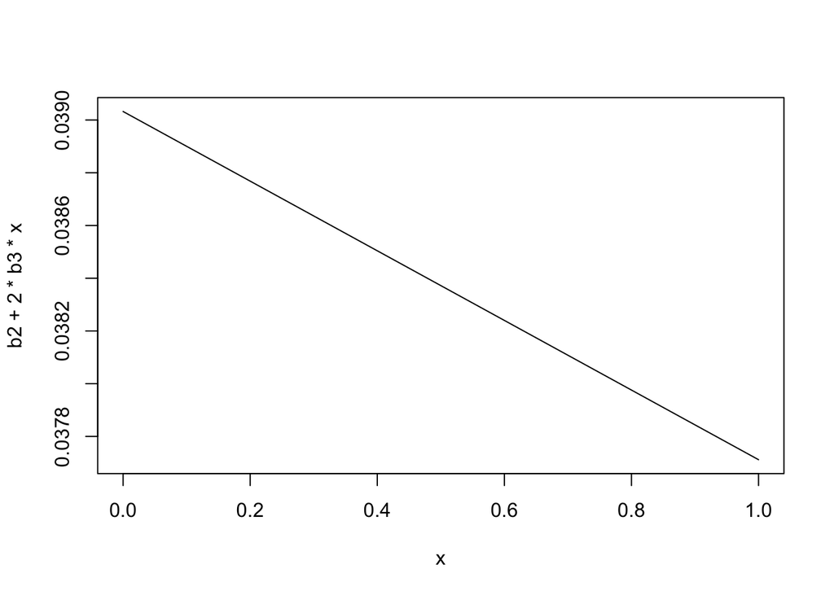

```r
# Notice there is a lot more information here, but we can get what we need from the first column
b2 <- exp2regsum$coefficients[3,1]
b3 <- exp2regsum$coefficients[4,1]

# We can now plot the marginal effects
curve(b2 + 2*b3*x)
```

The above graph could be improved upon quite a bit. First, note that the label for the axis is not very informative. Second, note that the range of experience (0 to 1) is a bit odd in the sense that most people in our sample will have a much larger number of years of experience. Let’s fix these two issues.

```r
# To know what is the appropriate range of experience, we should look at the data
# The summary function is also helpful for this -> just need to assign it the data we want analyzed
summary(cps$exper)
```

```
##    Min. 1st Qu.  Median    Mean 3rd Qu.    Max.
##    0.00   10.00   19.00   19.04   27.00   52.00
```

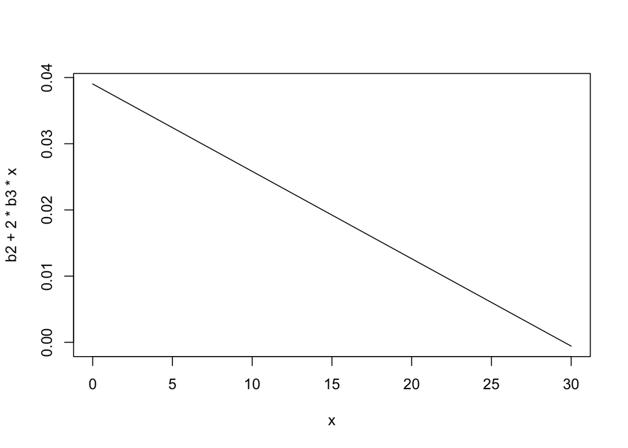

```r
# From the output, we see in our data years of experience goes from 0 to 52. Let's graph from 0 to 30 as a typical career.
curve(b2 + 2*b3*x, from = 0, to = 30)
```

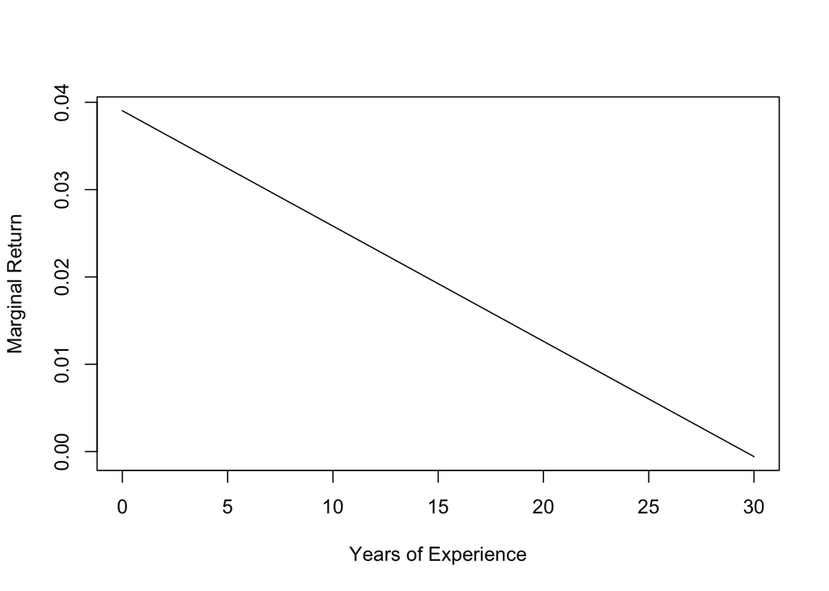

```r
# And to add labels, we just need the xlab and ylab arguments
curve(b2 + 2*b3*x, from = 0, to = 30, xlab = "Years of Experience", ylab = "Marginal Return")
```

The graph makes it very clear that the marginal returns to additional years of experience is decreasing. However, marginal returns are also positive and it would be helpful to plot the returns as a function of experience (rather than its derivative). One challenge is that the function
$$\beta_0+ \beta_1\text{edu} + \beta_2 \text{exper} + \beta_3 \text{exper}^2$$
depends on both experience and education. To plot how the function changes with experience, it is therefore customary to fix education at some level. Let’s try this by plotting how expected wages change with experience for some one with twelve years of education (the equivalent of a high-school degree)

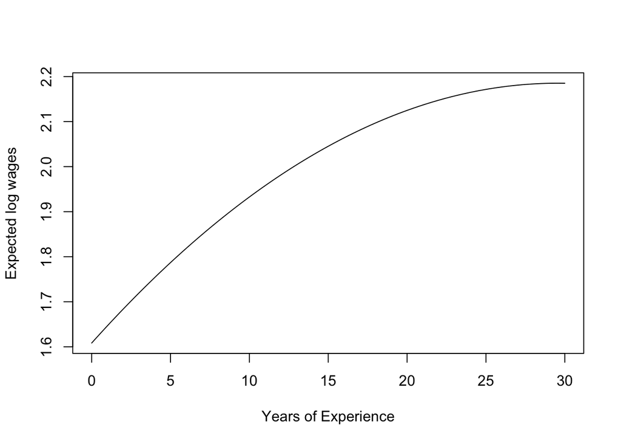

```r
# To graph the above function at edu = 12, we will need also beta hat 0 and beta hat 1
b0 <- exp2regsum$coefficients[1,1]
b1 <- exp2regsum$coefficients[2,1]

# Next we can graph this function
curve(b0 + b1*12 + b2*x + b3*x^2, from = 0, to = 30, xlab = "Years of Experience", ylab ="Expected log wages")
```

To test your understanding you should try to estimate the following model, which interacts education with experience:
$$\log(\text{wages}) = \beta_0 + \beta_1 \text{edu} + \beta_2 \text{exper} + \beta_3 \text{exper}\times \text{edu}.$$

- Plot marginal returns to experience for someone with 12 years of education
- Plot returns to experience for someone with 12 years of education

## Some Inference

To conclude we will see how to construct confidence intervals and do a hypothesis test on the coefficients of a linear regression. We will be brief because the analysis is virtually identical to what we did in the simple regression case.

Let’s start with building a confidence interval for a coefficient in a multiple regression model. Remember that the basic formula is given by
$$\hat{\beta}_j \pm z_{\frac{\alpha}{2}}\sqrt{\widehat{\text{Var}}(\hat{\beta}_j)}$$
Superficially, these formulas are exactly the same as in the single regression case. The main difference is in how $\widehat{\text{Var}}(b_j)$ is calculated, but that part is done in the background by R. Going back to the model
$$\log(\text{wages}) = \beta_0 + \beta_1 \text{edu} + \beta_2 \text{exper} + \beta_3 \text{exper}^2 + \epsilon$$
let’s obtain a confidence interval for $\beta_1$ (the coefficient in front of education). We’ll first clean the workspace and run the regression – here we are cleaning the workspace just because we have a lot of leftover variables from before.

```r
# We've done quite a bit, so let's start fresh and reload the data
# Clear the workspace
rm(list = ls())

# Our data set is store as part of the PoEData library, so let's tell R we need access to it
library(PoEdata)

# Looking at the output, there are multiple datasets called CPS. We'll use cps.
data(cps)

# Estimate the regression we want
regout <- lm(log(wage) ~ educ + exper + I(exper^2), data = cps)

# And the summary analysis
regsum <- summary(regout)
```

Next, we’ll build a 95$\%$ confidence region using a normal approximation. From our formulas, the main things we need to build the confidence intervals are the estimate, the standard error, and the quantile $z_{\frac{\alpha}{2}}$.

```r
# Recall a lot of the information we need is in regsum$coefficients
regsum$coefficients
```

```
##                  Estimate   Std. Error    t value      Pr(>|t|)
## (Intercept)  0.3172975760 4.289690e-02   7.396748  1.642254e-13
## educ         0.1075868690 2.919272e-03  36.854010 1.329181e-261
## exper        0.0390321653 2.041412e-03  19.120181  1.477104e-78
## I(exper^2)  -0.0006601511 4.777716e-05 -13.817295  1.335339e-42
```

```r
# Looking at the output, note the estimate b2 is in row 2, column 1
b2 <- regsum$coefficients[2,1]

# Similarly the standard error is in row 2, column 2
se2 <- regsum$coefficients[2,2]

# Now for the normal approximation all we need is z_{alpha/2}
# For a 95% confidence interval, alpha = 0.05 so we want the 1-0.05/2 quantile of a standard normal
za <- qnorm(1-0.05/2)

# For the CI just apply out formula
zlb <- b2 - se2*za
zub <- b2 + se2*za

# Print out
zlb
```

```
## [1] 0.1018652
```

```r
zub
```

```
## [1] 0.1133085
```

Finally, it is also helpful to note that we can use the function `confint` to build confidence intervals. Simply apply it to the `lm` output to get an answer

```r
# Call the function confint to get a confidence interval
confint(regout)
```

```
##                     2.5 %        97.5 %
## (Intercept)  0.2331996629  0.4013954891
## educ         0.1018637369  0.1133100012
## exper        0.0350300472  0.0430342834
## I(exper^2)  -0.0007538166 -0.0005664856
```

```r
# We already have all the elements we need. Just recall the function for P(Z <= a) is pnorm
pval <- 1 - pnorm((0.12-b2)/se2)

# Print answer
pval
```

```
## [1] 1.058721e-05
```

Notice that the p-value is very small so that we would reject at most conventional levels. To test your understanding, try the following problems:

- Obtain a pvalue using a normal approximation for the null hypothesis that $\beta_2 = 0.12$ against $\beta_2 > 0.12$.
- Obtain a pvalue using a normal approximation for the null hypothesis that $\beta_2 = 0.12$ against $\beta_2 < 0.12$.